# index

Decoding Diabetes: A Data-Driven Approach to Understanding Racial Disparities in Health

By: Aditya Krishnan, Ashwin Nathan, and Suraj Modur

**Introduction:**

Minority groups in the US have been severely harmed by systemic gaps in healthcare access, especially when it comes to chronic illnesses like type 2 diabetes. Minority populations encounter a multitude of obstacles, such as restricted availability of healthcare services and elevated incidence of underinsurance or uninsurance as a result of working in low-wage industries. As a result, among minorities, diseases like diabetes, hypertension, and cancer are frequently detected at a later stage, impeding early management and aggravating health disparities. Minority populations have disproportionately high rates of illness and mortality when compared to non-minority groups, which is the result of delayed diagnosis and treatment that perpetuates cycles of poor health outcomes.

Addressing these gaps requires an understanding of the intricate interactions that exist between chronic illnesses, healthcare access, and race. Promoting fair healthcare practices and regulations is crucial to reducing the structural obstacles that impede minority populations' access to high-quality medical treatment. Through an examination of the relationship between race, access to healthcare, and the occurrence of long-term illnesses such as type 2 diabetes, we may illuminate the extent of these differences and endeavor to advance health equity for all groups.

In this project, we are going to take a deeper dive at state level into whether there really is a correlation between race and health and how large of a role it plays. We will be analyzing multiple factors that can play a part, and look into the data to make predictions about the potential damage this can do to minority communities in the United States.

```python
# imports
import requests
import pandas as pd
import matplotlib.pyplot as plt
import numpy as np
from bs4 import BeautifulSoup as bs
import seaborn as sns
import warnings
warnings.filterwarnings("ignore", category=FutureWarning)
warnings.filterwarnings("ignore", category=UserWarning)
warnings.filterwarnings("ignore", category=DeprecationWarning)

from sklearn.model_selection import train_test_split
from sklearn.metrics import mean_squared_error, r2_score
from sklearn.linear_model import LinearRegression
from sklearn.preprocessing import StandardScaler
from sklearn.svm import SVR
from sklearn.neighbors import KNeighborsRegressor
```

**Data Collection**

```python
# we use OpenPyxl to be able to open our imported excel sheets
%pip install openpyxl
```

The first dataset that we will be taking a look at comes from the CDC. If you want to take a deeper look at some of the statistics provided by the CDC using data from the census, you can find it at https://www.census.gov/data/tables/2024/demo/hhp/cycle03.html#detail. Under their Health section, we used Table 3A, "Current Health Insurance Status by Select Characteristics". The first couple of rows are filler rows and column headers. We will deal with manipulating this table in Data Processing.

```python
dataset= pd.read_excel("health3a_cycle03.xlsx", header=4)
dataset.head()
```

|  | Select characteristics | Insured* | Insured*.1 | Insured*.2 | Uninsured | Did not report or don’t know |
| --- | --- | --- | --- | --- | --- | --- |
| 0 | NaN | Total | Private | Public | NaN | NaN |
| 1 | NaN | NaN | NaN | NaN | NaN | NaN |
| 2 | Total | 186940769 | 148001316 | 77254096 | 14657397.0 | 54713394.0 |
| 3 | Age | NaN | NaN | NaN | NaN | NaN |
| 4 | 18 - 24 | 10174610 | 8775953 | 2519121 | 1421440.0 | 6329440.0 |

Now that we have a better idea of how many people are uninsured for every race, we want to take a deeper dive into every state for every race. To do this, we use the dataset from KFF (https://www.kff.org/other/state-indicator/uninsured-rates-for-the-nonelderly-by-race-ethnicity-cps/?currentTimeframe=0&sortModel=%7B%22colId%22:%22Location%22,%22sort%22:%22asc%22%7D). This dataset gives us a better idea of the percentage of people who don't have health insurance for every state.

```python
insurance_state_df= pd.read_csv("uninsurnace_per_state.csv")
insurance_state_df.head()
```

|  | Location | White | Black | Hispanic | Asian/Native Hawaiian and Pacific Islander | American Indian/Alaska Native | Multiple Races | Total |
| --- | --- | --- | --- | --- | --- | --- | --- | --- |
| 0 | United States | 0.065 | 0.096 | 0.194 | 0.068 | 0.19 | 0.068 | 0.098 |
| 1 | Alabama | 0.070 | 0.098 | 0.230 | NaN | NaN | NaN | 0.091 |
| 2 | Alaska | 0.079 | NaN | NaN | NaN | 0.47 | 0.231 | 0.163 |
| 3 | Arizona | 0.080 | NaN | 0.174 | NaN | NaN | NaN | 0.120 |
| 4 | Arkansas | 0.093 | 0.109 | 0.220 | NaN | NaN | NaN | 0.109 |

Pulling from CDC Diabetes Dataset

The dataframe below has data pulled from CDC's National Diabetes Statistics Report. This data has the most up to date information on prevalence and incidence of diabetes. This website provides many tables that show different parameters and their diabetes values.

The table below titled: Table 2. Crude prevalence of diagnosed diabetes by detailed race and ethnicity among adults aged 18 years or older, United States. This table provides a breakdown of twenty races and their total percent of diagnosed diabetes.

```python
r = requests.get('https://www.cdc.gov/diabetes/php/data-research/?CDC_AAref_Val=https://www.cdc.gov/diabetes/data/statistics-report/index.html')
data = r.text


# Parse the HTML content
soup = bs(data, 'html.parser')
# Find the table you're interested in, by an ID or the specific attributes
table = soup.findAll('div', {'class': 'table-responsive'})
# Locate the specific table based on its content

table_count = 0
diab_table = table
for tables in table:
    if table_count == 2:
        diab_table = tables
        break
    else:
        table_count+=1



rows = diab_table.find_all('tr')

# List to hold all rows as lists
table_data = []

#Iterate over rows and get columns
for row in rows:
    cols = row.find_all(['td', 'th'])
    cols = [ele.text.strip() for ele in cols]
    table_data.append(cols)

#Create a DataFrame from the list of rows

diabietes_df = pd.DataFrame(data=table_data[1:], columns=table_data[0])

#Display the DataFrame
diabietes_df
```

|  | Race and Ethnicity Subgroup | Total Percentage (95% CI) |
| --- | --- | --- |
| 0 | American Indian or Alaska Native, non-Hispanic | 16.0 (12.1–20.6) |
| 1 | Black, non-Hispanic | 12.5 (11.6–13.4) |
| 2 | Native Hawaiian or Other Pacific Islander, non... | 11.7 (7.4–17.2) |
| 3 | Asian, non-Hispanic | 9.2 (8.2–10.4) |
| 4 | Asian Indian, non-Hispanic | 10.8 (8.3–13.7) |
| 5 | Chinese, non-Hispanic | 7.1 (5.2–9.3) |
| 6 | Filipino, non-Hispanic | 12.2 (9.4–15.6) |
| 7 | Japanese, non-Hispanic | 6.8 (4.1–10.5) |
| 8 | Korean, non-Hispanic | 6.1 (3.8–9.1) |
| 9 | Vietnamese, non-Hispanic | 6.4 (3.7–10.0) |
| 10 | Other Asian, non-Hispanic | 8.9 (5.9–12.8) |
| 11 | Hispanic | 10.3 (9.4–11.1) |
| 12 | Mexican or Mexican American | 11.1 (9.9–12.3) |
| 13 | Central American | 7.3 (5.6–9.4) |
| 14 | South American | 5.0 (3.3–7.1) |
| 15 | Puerto Rican | 13.3 (11.0–15.9) |
| 16 | Cuban | 9.0 (6.5–12.1) |
| 17 | Dominican | 9.4 (5.9–14.2) |
| 18 | Other Hispanic, Latino, or Spanish | 7.2 (5.5–9.2) |
| 19 | White, non-Hispanic | 8.5 (8.2–8.8) |

We will be looking at the data for food deserts and looking at for each state, the cumulative race in each state and how many people don't have quick access to a supermarket. This data organizes its data by state and county. We decided that we wanted to look at it as a state level issue, so we decided to sum all the numbers by each county of every state to get a better idea of how many people in a state were dealing with food desserts. This data set came from a Kaggle Dataset (https://www.kaggle.com/code/kerneler/starter-food-deserts-in-the-u-s-3f49ae84-7).

```python
df1= pd.read_csv("food_access_research_atlas.csv")
df1
```

|  | CensusTract | State | County | Urban | POP2010 | OHU2010 | GroupQuartersFlag | NUMGQTRS | PCTGQTRS | LILATracts_1And10 | ... | TractSeniors | TractWhite | TractBlack | TractAsian | TractNHOPI | TractAIAN | TractOMultir | TractHispanic | TractHUNV | TractSNAP |
| --- | --- | --- | --- | --- | --- | --- | --- | --- | --- | --- | --- | --- | --- | --- | --- | --- | --- | --- | --- | --- | --- |
| 0 | 1001020100 | Alabama | Autauga | 1 | 1912 | 693 | 0 | 0 | 0.000000 | 0 | ... | 221 | 1622 | 217 | 14 | 0 | 14 | 45 | 44 | 26 | 112 |
| 1 | 1001020200 | Alabama | Autauga | 1 | 2170 | 743 | 0 | 181 | 0.083410 | 0 | ... | 214 | 888 | 1217 | 5 | 0 | 5 | 55 | 75 | 87 | 202 |
| 2 | 1001020300 | Alabama | Autauga | 1 | 3373 | 1256 | 0 | 0 | 0.000000 | 0 | ... | 439 | 2576 | 647 | 17 | 5 | 11 | 117 | 87 | 108 | 120 |
| 3 | 1001020400 | Alabama | Autauga | 1 | 4386 | 1722 | 0 | 0 | 0.000000 | 0 | ... | 904 | 4086 | 193 | 18 | 4 | 11 | 74 | 85 | 19 | 82 |
| 4 | 1001020500 | Alabama | Autauga | 1 | 10766 | 4082 | 0 | 181 | 0.016812 | 0 | ... | 1126 | 8666 | 1437 | 296 | 9 | 48 | 310 | 355 | 198 | 488 |
| ... | ... | ... | ... | ... | ... | ... | ... | ... | ... | ... | ... | ... | ... | ... | ... | ... | ... | ... | ... | ... | ... |
| 72859 | 56043000200 | Wyoming | Washakie | 0 | 3326 | 1317 | 0 | 57 | 0.017138 | 0 | ... | 593 | 3106 | 6 | 15 | 0 | 27 | 172 | 309 | 56 | 116 |
| 72860 | 56043000301 | Wyoming | Washakie | 1 | 2665 | 1154 | 0 | 10 | 0.003752 | 0 | ... | 399 | 2377 | 5 | 23 | 0 | 40 | 220 | 446 | 114 | 124 |
| 72861 | 56043000302 | Wyoming | Washakie | 1 | 2542 | 1021 | 0 | 73 | 0.028717 | 0 | ... | 516 | 2312 | 11 | 10 | 1 | 26 | 182 | 407 | 82 | 97 |
| 72862 | 56045951100 | Wyoming | Weston | 0 | 3314 | 1322 | 0 | 252 | 0.076041 | 0 | ... | 499 | 3179 | 15 | 10 | 1 | 47 | 62 | 91 | 108 | 50 |
| 72863 | 56045951300 | Wyoming | Weston | 1 | 3894 | 1699 | 0 | 61 | 0.015665 | 0 | ... | 650 | 3706 | 6 | 10 | 2 | 44 | 126 | 125 | 95 | 168 |

72864 rows × 147 columns

The dataframe below is data pulled from the CDC on estimated crude prevalence of diagnosed diabetes, undiagnosed diabetes, and total diabetes among adults aged 18 years or older, United States. It provides numeric values for a number of parameters such as age, race, and sex. This will be used later to visualize the data.

```python
r = requests.get('https://www.cdc.gov/diabetes/php/data-research/?CDC_AAref_Val=https://www.cdc.gov/diabetes/data/statistics-report/index.html')
data = r.text


# Parse the HTML content
soup = bs(data, 'html.parser')
# Find the table you're interested in, by an ID or the specific attributes
table = soup.find('div', {'class': 'table-responsive'})
rows = table.find_all('tr')
table_data = []
for row in rows:
    cols = row.find_all(['td','th'])
    cols = [ele.text.strip() for ele in cols]
    table_data.append(cols)

#Create a DataFrame from the list of rows
ethnic_df = pd.DataFrame(table_data)
ethnic_df
```

|  | 0 | 1 | 2 | 3 |
| --- | --- | --- | --- | --- |
| 0 | Characteristic | Diagnosed diabetes Percentage\r\n(95% CI) | Undiagnosed diabetes Percentage\r\n(95% CI) | Total diabetes Percentage\r\n(95% CI) |
| 1 | Total | 11.3 (10.3–12.5) | 3.4 (2.7–4.2) | 14.7 (13.2–16.4) |
| 2 | Age in years | None | None | None |
| 3 | 18–44 | 3.0 (2.4–3.7) | 1.9 (1.3–2.7) | 4.8 (4.0–5.9) |
| 4 | 45–64 | 14.5 (12.2–17.0) | 4.5 (3.3–6.0) | 18.9 (16.1–22.1) |
| 5 | ≥65 | 24.4 (22.1–27.0) | 4.7 (3.0–7.4) | 29.2 (26.4–32.1) |
| 6 | Sex | None | None | None |
| 7 | Men | 12.6 (11.1–14.3) | 2.8 (2.0–3.9) | 15.4 (13.5–17.5) |
| 8 | Women | 10.2 (8.8–11.7) | 3.9 (2.7–5.5) | 14.1 (11.8–16.7) |
| 9 | Race-Ethnicity | None | None | None |
| 10 | White, non-Hispanic | 11.0 (9.4–12.8) | 2.7 (1.7–4.2) | 13.6 (11.4–16.2) |
| 11 | Black, non-Hispanic | 12.7 (10.7–15.0) | 4.7 (3.3–6.5) | 17.4 (15.2–19.8) |
| 12 | Asian, non-Hispanic | 11.3 (9.7–13.1) | 5.4 (3.5–8.3) | 16.7 (14.0–19.8) |
| 13 | Hispanic | 11.1 (9.5–13.0) | 4.4 (3.3–5.8) | 15.5 (13.8–17.3) |

We want to be able to analyze the number of diagnosed diabetics per state per race. To get this, we will be using the data table from the CDC archives found at this link: https://archive.cdc.gov/#/details?q=diabetes&start=0&rows=10&url=https://www.cdc.gov/diabetes/library/reports/reportcard/national-state-diabetes-trends.html. The data from this was put into an Excel sheet, but you can access the data on this website. This dataset gives us the percentage of Adults 18 or older with diagnosed diabetes.

```python
percent_diabetes= pd.read_excel("percent_diabetes_per_state.xlsx")
numeric_columns = percent_diabetes.select_dtypes(include=['number']).columns
percent_diabetes[numeric_columns] /= 100
percent_diabetes.head()
```

|  | State | Percentage of Adults 18 or Older With Diagnosed Diabetes |
| --- | --- | --- |
| 0 | Alabama | 0.127 |
| 1 | Alaska | 0.087 |
| 2 | Arizona | 0.096 |
| 3 | Arkansas | 0.124 |
| 4 | California | 0.097 |

The data below is taken from a dataset provided by Peter G Peterson Foundation which gives data on income and wealth in the United States for 2021 and 2022 based on a number of factors. The table below is data just on the four races, Asian, Hispanic, Black, and White and their median yearly income.

```python
r = requests.get('https://www.pgpf.org/blog/2024/05/income-and-wealth-in-the-united-states-an-overview-of-recent-data')
data = r.text
soup = bs(data, 'html.parser')
# Find the table you're interested in, by an ID or the specific attributes
table = soup.findAll('figure', {'class': 'chart'})

table_count = 0
main_table = table
for tables in table:
    if table_count == 2:
        main_table = tables
        break
    else:
        table_count+=1

rows = main_table.find_all('tr')


table_data = []

for row in rows:
    cols = row.find_all(['td', 'th'])
    cols = [ele.text.strip() for ele in cols]
    table_data.append(cols)

#Create a DataFrame from the list of rows

income_df = pd.DataFrame(data=table_data[1:], columns=table_data[0])

#Display the DataFrame
income_df
```

|  | Race/Ethnicity of Household Head | 2021 Median Household Income (2022 dollars) | 2022 Median Household Income |
| --- | --- | --- | --- |
| 0 | All races/ethnicities | $76,330 | $74,580 |
| 1 | Asian* | $109,400 | $108,700 |
| 2 | White, not Hispanic | $84,110 | $81,060 |
| 3 | Hispanic (any race)* | $62,520 | $62,800 |
| 4 | Black* | $52,080 | $52,860 |

Now that we have a better idea of how the income is separated in the United States, we want to look at this at a state level. We can see that Asian people have the highest Median household income, followed by White, then Hispanic, then Black for both 2022 and 2021. We will use the dataset from the Department of Labor (https://www.dol.gov/agencies/ofccp/about/data/earnings/race-and-ethnicity#) to get a better understanding of the average salary per week per race of every state.

```python
earnings_df= pd.read_excel("Earnings Disparity Race and Ethnicity Data.xlsx")
earnings_df.head(20)
```

|  | State | Data Type | Average Weekly Earnings | Number of Workers | Earnings Disparity | Employed Percent |
| --- | --- | --- | --- | --- | --- | --- |
| 0 | NATIONAL | White | 1046.516480 | 9.748495e+07 | 1.000000 | 0.626741 |
| 1 | NATIONAL | Black | 791.005786 | 1.778119e+07 | 0.755846 | 0.114317 |
| 2 | NATIONAL | Native American/American Indian | 801.989267 | 1.037819e+06 | 0.766342 | 0.006672 |
| 3 | NATIONAL | Asian-Pacific Islander | 1168.821931 | 1.007128e+07 | 1.116869 | 0.064749 |
| 4 | NATIONAL | Hispanic/Latino | 762.795413 | 2.684918e+07 | 0.728890 | 0.172616 |
| 5 | NATIONAL | Multiracial | 852.178804 | 2.318129e+06 | 0.814300 | 0.014904 |
| 6 | AK | White | 1122.683589 | 2.119601e+05 | 1.000000 | 0.638335 |
| 7 | AK | Black | 879.662853 | 9.411074e+03 | 0.783536 | 0.028342 |
| 8 | AK | Native American/American Indian | 934.037487 | 3.928662e+04 | 0.831969 | 0.118315 |
| 9 | AK | Asian-Pacific Islander | 758.479196 | 3.152184e+04 | 0.675595 | 0.094931 |
| 10 | AK | Hispanic/Latino | 845.618648 | 2.099904e+04 | 0.753212 | 0.063240 |
| 11 | AK | Multiracial | 815.775171 | 1.887301e+04 | 0.726630 | 0.056838 |
| 12 | AL | White | 956.799950 | 1.435064e+06 | 1.000000 | 0.675306 |
| 13 | AL | Black | 705.746194 | 5.271288e+05 | 0.737611 | 0.248054 |
| 14 | AL | Native American/American Indian | 904.673332 | 1.327680e+04 | 0.945520 | 0.006248 |
| 15 | AL | Asian-Pacific Islander | 1151.021560 | 3.168386e+04 | 1.202991 | 0.014910 |
| 16 | AL | Hispanic/Latino | 686.070255 | 9.065800e+04 | 0.717047 | 0.042661 |
| 17 | AL | Multiracial | 699.522091 | 2.724539e+04 | 0.731106 | 0.012821 |
| 18 | AR | White | 885.001236 | 9.589602e+05 | 1.000000 | 0.733707 |
| 19 | AR | Black | 690.691120 | 1.904005e+05 | 0.780441 | 0.145677 |

**Data Processing**

This dataset contained a lot of characteristics that we didn't deem necessary for our project, such as Age, Sexual Orientation, and Gender. As a result, we had to manipulate our dataframe to only get information we needed. We started by removing the bottom 2 rows, which were rows of NaN used as filler rows in the data. We also had to drop the first row because the data table used 2 rows for the column headers.

To actually remove the characteristics we didn't need, we saw that was between the first 29, and the last 90, so we removed those from the dataset using the iloc method. After resetting the index again, we had all the correct information we needed.

```python
# Remove the last 2 rows
dataset = dataset.iloc[:-2]

# Reset the index after removing rows
dataset.reset_index(drop=True, inplace=True)
dataset.drop(1, inplace=True)
dataset= dataset.iloc[29:]
dataset= dataset.iloc[:-90]
dataset.reset_index(drop=True, inplace= True)
dataset.rename(columns={'Select characteristics' : 'Race', 'Insured*': 'Total Insured', 'Insured*.1': 'Public Insurance', 'Insured*.2': 'Private Insurance'}, inplace=True)
pd.set_option('display.max_rows', None)
dataset = dataset.iloc[1:]

dataset

#Insured*= Total Insured
#Insured*.1= Public Insurance
#Insured*.2= Private Insurance
```

|  | Race | Total Insured | Public Insurance | Private Insurance | Uninsured | Did not report or don’t know |
| --- | --- | --- | --- | --- | --- | --- |
| 1 | Hispanic or Latino (may be of any race) | 28594943 | 22330974 | 11307990 | 4700338.0 | 12541204.0 |
| 2 | White alone, not Hispanic | 120334473 | 95459488 | 50335257 | 7194362.0 | 28414253.0 |
| 3 | Black alone, not Hispanic | 20365046 | 15427319 | 9563661 | 1577562.0 | 8401276.0 |
| 4 | Asian alone, not Hispanic | 9918919 | 8659300 | 2914955 | 422563.0 | 2895878.0 |
| 5 | Two or more races + Other races, not Hispanic | 7727388 | 6124236 | 3132232 | 762572.0 | 2460784.0 |

When looking at the insurance dataset, we can see that there are extra ethnicities that we are not focusing on, and also a total column. Since we are not looking at those races, we can remove those columns.

```python
insurance_state_df.drop(columns=["American Indian/Alaska Native", "Multiple Races", "Total"], inplace=True)
insurance_state_df= insurance_state_df.iloc[1:]
insurance_state_df.head()
```

|  | Location | White | Black | Hispanic | Asian/Native Hawaiian and Pacific Islander |
| --- | --- | --- | --- | --- | --- |
| 1 | Alabama | 0.070 | 0.098 | 0.230 | NaN |
| 2 | Alaska | 0.079 | NaN | NaN | NaN |
| 3 | Arizona | 0.080 | NaN | 0.174 | NaN |
| 4 | Arkansas | 0.093 | 0.109 | 0.220 | NaN |
| 5 | California | 0.043 | 0.073 | 0.137 | 0.049 |

Another issue that we can see is that some ethnicities are labeled with NaN. Some data table manipulation that we will be doing is that for every state that says NaN, we will be replacing it with the country average.

```python
average_data= dataset['Uninsured'] / (dataset['Total Insured']+dataset['Uninsured'])
hispanic_average= average_data[1]
white_average= average_data[2]
black_average= average_data[3]
asian_average=average_data[4]
hispanic_average = "{:.3f}".format(hispanic_average)
white_average = "{:.3f}".format(white_average)
black_average = "{:.3f}".format(black_average)
asian_average = "{:.3f}".format(asian_average)

insurance_state_df['Hispanic'].fillna(hispanic_average, inplace=True)
insurance_state_df['White'].fillna(white_average, inplace=True)
insurance_state_df['Black'].fillna(black_average, inplace=True)
insurance_state_df['Asian/Native Hawaiian and Pacific Islander'].fillna(asian_average, inplace=True)

insurance_state_df = insurance_state_df.iloc[:51]
insurance_state_df = insurance_state_df.reset_index(drop=True)
insurance_state_df.head(10)
```

|  | Location | White | Black | Hispanic | Asian/Native Hawaiian and Pacific Islander |
| --- | --- | --- | --- | --- | --- |
| 0 | Alabama | 0.07 | 0.098 | 0.23 | 0.041 |
| 1 | Alaska | 0.079 | 0.072 | 0.141 | 0.041 |
| 2 | Arizona | 0.08 | 0.072 | 0.174 | 0.041 |
| 3 | Arkansas | 0.093 | 0.109 | 0.22 | 0.041 |
| 4 | California | 0.043 | 0.073 | 0.137 | 0.049 |
| 5 | Colorado | 0.055 | 0.072 | 0.158 | 0.041 |
| 6 | Connecticut | 0.04 | 0.072 | 0.155 | 0.041 |
| 7 | Delaware | 0.051 | 0.072 | 0.255 | 0.041 |
| 8 | District of Columbia | 0.056 | 0.079 | 0.141 | 0.041 |
| 9 | Florida | 0.124 | 0.14 | 0.213 | 0.174 |

```python
cumulative_table = df1.groupby(['State']).sum()
cumulative_table.drop(columns=['County', 'Urban', 'GroupQuartersFlag', 'NUMGQTRS'], inplace=True)
cumulative_table.drop(columns=['PCTGQTRS', 'HUNVFlag', 'PovertyRate', 'MedianFamilyIncome'], inplace=True)
cumulative_table.drop(columns=['LA1and10', 'LAhalfand10', 'LA1and20', 'LATracts_half', 'LATracts1'], inplace=True)
cumulative_table.drop(columns=['LATracts10', 'LATracts20', 'LATractsVehicle_20', 'LAPOP1_10', 'LAPOP05_10'], inplace=True)
cumulative_table.drop(columns=['LAPOP1_20', 'LALOWI1_10', 'LALOWI05_10', 'LALOWI1_20', 'lapophalf'], inplace=True)
cumulative_table.drop(columns=['lapophalfshare', 'lalowihalf','lalowihalfshare', 'lakidshalf','lakidshalfshare', 'laseniorshalf'], inplace=True)
cumulative_table.drop(columns=['laseniorshalfshare', 'lawhitehalf', 'lawhitehalfshare', 'lablackhalf', 'lablackhalfshare', 'laasianhalf', 'laasianhalfshare'], inplace=True)
cumulative_table.drop(columns=['lanhopihalf', 'lanhopihalfshare', 'laaianhalf', 'laaianhalfshare', 'laomultirhalf', 'laomultirhalfshare'], inplace=True)
cumulative_table.drop(columns=['lahisphalf', 'lahisphalfshare', 'lahunvhalf', 'lahunvhalfshare', 'lasnaphalf'], inplace=True)
cumulative_table.drop(columns=['lasnaphalfshare', 'lapop1', 'lapop1share', 'lalowi1', 'lalowi1share', 'lakids1', 'lakids1share', 'laseniors1', 'laseniors1share', 'lawhite1'], inplace=True)
cumulative_table.drop(columns=['lawhite1share', 'lablack1', 'lablack1share', 'laasian1', 'laasian1share', 'lanhopi1', 'lanhopi1share', 'laaian1', 'laaian1share'], inplace=True)
cumulative_table.drop(columns=['laomultir1', 'laomultir1share', 'lahisp1', 'lahisp1share', 'lahunv1', 'lahunv1share', 'lasnap1', 'lasnap1share'], inplace=True)
cumulative_table.drop(columns=['lapop10', 'lapop10share', 'lalowi10', 'lalowi10share', 'lakids10', 'lakids10share', 'laseniors10', 'laseniors10share'], inplace=True)
cumulative_table.drop(columns=['lawhite10', 'lawhite10share', 'lablack10', 'lablack10share', 'laasian10', 'laasian10share', 'lanhopi10', 'lanhopi10share'], inplace=True)
cumulative_table.drop(columns=['laaian10', 'laaian10share', 'laomultir10', 'laomultir10share', 'lahisp10', 'lahisp10share', 'lahunv10', 'lahunv10share'], inplace=True)
cumulative_table.drop(columns=['lasnap10', 'lasnap10share', 'lapop20', 'lapop20share', 'lalowi20', 'lalowi20share', 'lakids20', 'lakids20share'], inplace=True)
cumulative_table.drop(columns=['laseniors20', 'laseniors20share', 'lawhite20', 'lawhite20share', 'lablack20', 'lablack20share', 'laasian20', 'laasian20share'], inplace=True)
cumulative_table.drop(columns=['lanhopi20', 'lanhopi20share', 'laaian20', 'laaian20share', 'laomultir20', 'laomultir20share', 'lahisp20', 'lahisp20share'], inplace=True)
cumulative_table.drop(columns=['lahunv20', 'lahunv20share', 'lasnap20', 'lasnap20share'], inplace=True)

columns_to_sum = ['LILATracts_1And10', 'LILATracts_halfAnd10', 'LILATracts_1And20', 'LILATracts_Vehicle', 'LowIncomeTracts']

# Add a new column 'LILATRACTS' by summing the specified columns for every row
cumulative_table['LILATRACTS'] = cumulative_table[columns_to_sum].sum(axis=1)


cumulative_table.head(10)
```

| State | CensusTract | POP2010 | OHU2010 | LILATracts_1And10 | LILATracts_halfAnd10 | LILATracts_1And20 | LILATracts_Vehicle | LowIncomeTracts | TractLOWI | TractKids | ... | TractWhite | TractBlack | TractAsian | TractNHOPI | TractAIAN | TractOMultir | TractHispanic | TractHUNV | TractSNAP | LILATRACTS |
| --- | --- | --- | --- | --- | --- | --- | --- | --- | --- | --- | --- | --- | --- | --- | --- | --- | --- | --- | --- | --- | --- |
| Alabama | 1268834272385 | 4779736 | 1883791 | 246 | 387 | 200 | 257 | 627 | 1887965 | 1132459 | ... | 3275394 | 1251311 | 53595 | 3057 | 28218 | 168161 | 185602 | 119315 | 291592 | 1717 |
| Alaska | 351542086585 | 710231 | 258058 | 34 | 48 | 29 | 35 | 54 | 186291 | 187378 | ... | 473576 | 23263 | 38135 | 7409 | 104871 | 62977 | 39249 | 24148 | 26130 | 200 |
| Arizona | 6126991377194 | 6392017 | 2380990 | 258 | 564 | 229 | 253 | 667 | 2501147 | 1629014 | ... | 4667121 | 259008 | 176695 | 12648 | 296529 | 980016 | 1895149 | 163479 | 323640 | 1971 |
| Arkansas | 3484080853747 | 2915918 | 1147084 | 177 | 247 | 124 | 154 | 342 | 1227601 | 711475 | ... | 2245229 | 449895 | 36102 | 5863 | 22248 | 156581 | 186050 | 72003 | 167466 | 1044 |
| California | 48705669364530 | 37253956 | 12577498 | 542 | 2195 | 506 | 612 | 3535 | 13575487 | 9295040 | ... | 21453934 | 2299072 | 4861007 | 144386 | 362801 | 8132756 | 14013719 | 984852 | 1102588 | 7390 |
| Colorado | 10050504751914 | 5029196 | 1972868 | 180 | 419 | 153 | 155 | 501 | 1532352 | 1225609 | ... | 4089202 | 201737 | 139028 | 6623 | 56010 | 536596 | 1038687 | 114782 | 171194 | 1408 |
| Connecticut | 7492871977935 | 3574097 | 1371087 | 70 | 203 | 70 | 118 | 289 | 823045 | 817015 | ... | 2772410 | 362296 | 135565 | 1428 | 11256 | 291142 | 479087 | 123437 | 157477 | 750 |
| Delaware | 2180705461177 | 897934 | 342297 | 27 | 55 | 27 | 27 | 82 | 254044 | 205765 | ... | 618617 | 191814 | 28549 | 400 | 4181 | 54373 | 73221 | 21841 | 43114 | 218 |
| District of Columbia | 1969180078485 | 601723 | 266707 | 6 | 52 | 6 | 45 | 102 | 191388 | 100815 | ... | 231471 | 305125 | 21056 | 302 | 2079 | 41690 | 54749 | 96855 | 37777 | 211 |
| Florida | 50870329497024 | 18801310 | 7420802 | 582 | 1301 | 540 | 654 | 1692 | 7211686 | 4002091 | ... | 14109162 | 2999862 | 454821 | 12286 | 71458 | 1153721 | 4223806 | 512040 | 1032766 | 4769 |

10 rows × 21 columns

```python
percentage_lila = (cumulative_table['LILATRACTS'] / cumulative_table['POP2010']) * 100
total_population = cumulative_table['POP2010']

cumulative_table['Total'] = cumulative_table[['TractWhite', 'TractBlack', 'TractAsian', 'TractHispanic']].sum(axis=1)

# Calculate the percentage of each race for each state
cumulative_table['PercentWhite'] = cumulative_table['TractWhite'] / cumulative_table['Total']
cumulative_table['PercentBlack'] = cumulative_table['TractBlack'] / cumulative_table['Total']
cumulative_table['PercentAsian'] = cumulative_table['TractAsian'] / cumulative_table['Total']
cumulative_table['PercentHispanic'] = cumulative_table['TractHispanic'] / cumulative_table['Total']

# Calculate the number of people in the LILA population per state
lila_population = (percentage_lila / 100) * total_population

# Calculate the number of people in the LILA population per race per state
lila_population_per_race = pd.DataFrame()

# Multiply the LILA population per state by the percentage of each race in each state to get the LILA population per race
for race in ['TractWhite', 'TractBlack', 'TractAsian', 'TractHispanic']:
    lila_population_per_race[race.replace('Tract', '')] = (cumulative_table[race] / 100) * lila_population

# Add 'State' column to the DataFrame
lila_population_per_race['State'] = cumulative_table.index

# Rearrange columns to have 'State' as the first column
lila_population_per_race = lila_population_per_race[['State', 'White', 'Black', 'Asian', 'Hispanic']]

# Reset index
lila_population_per_race.reset_index(drop=True, inplace=True)

multiplier = 1e-6  # Multiply each number by 10^(-6) to convert to millions. We're using a multiplier because the numbers are negligble otherwise

# Apply the multiplier to the DataFrame
scaled_lila_population_per_race = lila_population_per_race.copy()  # Create a copy of the DataFrame
scaled_lila_population_per_race[['White', 'Black', 'Asian', 'Hispanic']] *= multiplier  # Scale down the values in the specified columns

scaled_lila_population_per_race.head(20)
```

|  | State | White | Black | Asian | Hispanic |
| --- | --- | --- | --- | --- | --- |
| 0 | Alabama | 56.238515 | 21.485010 | 0.920226 | 3.186786 |
| 1 | Alaska | 0.947152 | 0.046526 | 0.076270 | 0.078498 |
| 2 | Arizona | 91.988955 | 5.105048 | 3.482658 | 37.353387 |
| 3 | Arkansas | 23.440191 | 4.696904 | 0.376905 | 1.942362 |
| 4 | California | 1585.445723 | 169.901421 | 359.228417 | 1035.613834 |
| 5 | Colorado | 57.575964 | 2.840457 | 1.957514 | 14.624713 |
| 6 | Connecticut | 20.793075 | 2.717220 | 1.016738 | 3.593152 |
| 7 | Delaware | 1.348585 | 0.418155 | 0.062237 | 0.159622 |
| 8 | District of Columbia | 0.488404 | 0.643814 | 0.044428 | 0.115520 |
| 9 | Florida | 672.865936 | 143.063419 | 21.690413 | 201.433308 |
| 10 | Georgia | 178.368901 | 90.932407 | 9.691873 | 26.310695 |
| 11 | Hawaii | 0.797740 | 0.050775 | 1.244435 | 0.286396 |
| 12 | Idaho | 3.952058 | 0.027762 | 0.053965 | 0.497800 |
| 13 | Illinois | 272.674726 | 55.451160 | 17.437809 | 60.239342 |
| 14 | Indiana | 99.406531 | 10.751597 | 1.862977 | 7.084873 |
| 15 | Iowa | 18.886799 | 0.605315 | 0.360508 | 1.028984 |
| 16 | Kansas | 21.208560 | 1.488954 | 0.601049 | 2.661373 |
| 17 | Kentucky | 51.200177 | 4.536269 | 0.657619 | 1.785316 |
| 18 | Louisiana | 50.682751 | 25.954317 | 1.253259 | 3.441047 |
| 19 | Maine | 3.415422 | 0.042409 | 0.036642 | 0.045725 |

Another thing we wanted to do in our data processing is we wanted to merge the percentage of people with diagnoed diabetes and the columns of percent of race per state so that we could get a side by side and be able to make sure the calculations were correct

```python
percent_diabetes=percent_diabetes.merge(cumulative_table[['PercentWhite', 'PercentBlack', 'PercentAsian', 'PercentHispanic']], left_on='State', right_index=True)
percent_diabetes.head()
```

|  | State | Percentage of Adults 18 or Older With Diagnosed Diabetes | PercentWhite | PercentBlack | PercentAsian | PercentHispanic |
| --- | --- | --- | --- | --- | --- | --- |
| 0 | Alabama | 0.127 | 0.687256 | 0.262555 | 0.011246 | 0.038944 |
| 1 | Alaska | 0.087 | 0.824725 | 0.040512 | 0.066411 | 0.068351 |
| 2 | Arizona | 0.096 | 0.666925 | 0.037012 | 0.025249 | 0.270814 |
| 3 | Arkansas | 0.124 | 0.769632 | 0.154217 | 0.012375 | 0.063775 |
| 4 | California | 0.097 | 0.503286 | 0.053934 | 0.114034 | 0.328747 |

```python
diabetes_per_race = pd.DataFrame()
diabetes_per_race['State'] = percent_diabetes['State']
diabetes_per_race['DiabetesWhite'] = percent_diabetes['Percentage of Adults 18 or Older With Diagnosed Diabetes'] * percent_diabetes['PercentWhite']
diabetes_per_race['DiabetesBlack'] = percent_diabetes['Percentage of Adults 18 or Older With Diagnosed Diabetes'] * percent_diabetes['PercentBlack']
diabetes_per_race['DiabetesAsian'] = percent_diabetes['Percentage of Adults 18 or Older With Diagnosed Diabetes'] * percent_diabetes['PercentAsian']
diabetes_per_race['DiabetesHispanic'] = percent_diabetes['Percentage of Adults 18 or Older With Diagnosed Diabetes'] * percent_diabetes['PercentHispanic']
diabetes_per_race.head()
```

|  | State | DiabetesWhite | DiabetesBlack | DiabetesAsian | DiabetesHispanic |
| --- | --- | --- | --- | --- | --- |
| 0 | Alabama | 0.087281 | 0.033344 | 0.001428 | 0.004946 |
| 1 | Alaska | 0.071751 | 0.003525 | 0.005778 | 0.005947 |
| 2 | Arizona | 0.064025 | 0.003553 | 0.002424 | 0.025998 |
| 3 | Arkansas | 0.095434 | 0.019123 | 0.001535 | 0.007908 |
| 4 | California | 0.048819 | 0.005232 | 0.011061 | 0.031888 |

```python
earnings_df.drop(columns=["Number of Workers", "Earnings Disparity", "Employed Percent"], inplace=True)
earnings_df= earnings_df[6:]
earnings_df = earnings_df[earnings_df['Data Type'] != 'Native American/American Indian']
earnings_df = earnings_df[earnings_df['Data Type'] != 'Multiracial']
earnings_df.reset_index(drop=True, inplace= True)
earnings_df.head()
```

|  | State | Data Type | Average Weekly Earnings |
| --- | --- | --- | --- |
| 0 | AK | White | 1122.683589 |
| 1 | AK | Black | 879.662853 |
| 2 | AK | Asian-Pacific Islander | 758.479196 |
| 3 | AK | Hispanic/Latino | 845.618648 |
| 4 | AL | White | 956.799950 |

Additionally, we want to manipulate the dataframe so that it looks at the rest of the data that we have been working with. To do this, we have to rotate our table so that each row is a state and every column is one of our ethnicities, with each data point being its corresponding average weekly income.

```python
pivoted_df = earnings_df.pivot(index='State', columns='Data Type', values='Average Weekly Earnings')
pivoted_df.reset_index(inplace=True)
pivoted_df.columns.name = None

pivoted_df.head()
```

|  | State | Asian-Pacific Islander | Black | Hispanic/Latino | White |
| --- | --- | --- | --- | --- | --- |
| 0 | AK | 758.479196 | 879.662853 | 845.618648 | 1122.683589 |
| 1 | AL | 1151.021560 | 705.746194 | 686.070255 | 956.799950 |
| 2 | AR | 913.959589 | 690.691120 | 678.354578 | 885.001236 |
| 3 | AZ | 1093.653095 | 761.827736 | 718.844158 | 1054.435662 |
| 4 | CA | 1278.067345 | 910.485635 | 781.737548 | 1261.061302 |

**Exploratory Analysis**

A helpful graphic for this dataset would be a bar graph of the percent of uninsured vs the total number of insured and uninsured so we could get a better idea of how each racial group stacked up against each other and who was the least and most insured.

Our prediction during the project was that groups that had a higher percentage of people uninsured were more likely to have Type 2 Diabetes because they don't have the ability to get it checked early. In an article by NCBI (https://www.ncbi.nlm.nih.gov/pmc/articles/PMC7369944/), they had concluded thru their own surveys that "having health insurance was associated with decreased odds for undiagnosed prediabetes and type 2 diabetes in American adults."

We calculated our Uninsured rate by first converting the dataset into numerics, and then getting the rate by dividing the number of uninsured by the total number of people insured and uninsured.

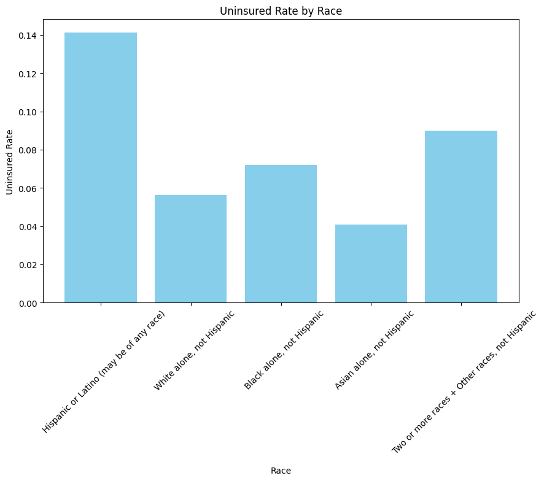

```python
dataset['Total Insured'] = pd.to_numeric(dataset['Total Insured'], errors='coerce')
dataset['Uninsured'] = pd.to_numeric(dataset['Uninsured'], errors='coerce')

dataset['Uninsured Rate'] = dataset['Uninsured'] / (dataset['Total Insured']+dataset['Uninsured'])
plt.figure(figsize=(10, 6))
plt.bar(dataset['Race'], dataset['Uninsured Rate'], color='skyblue')
plt.title('Uninsured Rate by Race')
plt.xlabel('Race')
plt.ylabel('Uninsured Rate')
plt.xticks(rotation=45)
plt.show()

# Using insurance rate per state, get rough idea per state per race uninsurance rate
```

Another thing we wanted to do when visualizing this data is to see the percent race is in each state. It was important for us to get a better understanding of the demographics of each state before we moved into making a connection between demographics and likeliness of being a food desert. To calculate the percent per state, looked at 4 races that we wanted to concentrate on: White, Black, Asian, and Hispanic. The first part is for each row, we divide the number of the race in the state by its total population. We then decided to make subplots of every state so we could compare each state next to each other, while labeling the state name, and the percentage race in each state. There is a key at the bottom that says what color is associated with what race.

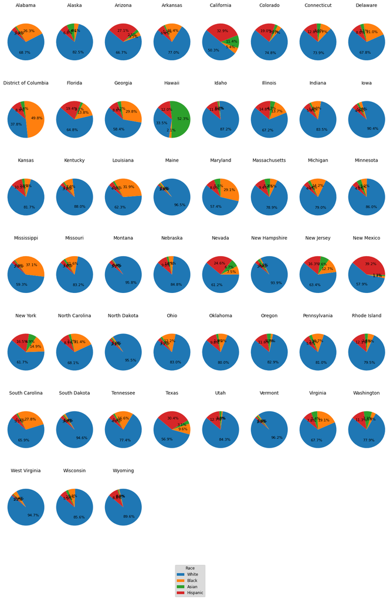

```python
cumulative_table['Total'] = cumulative_table.sum(axis=1)

# Calculate the percentage of each race for each state
cumulative_table['PercentWhite'] = cumulative_table['TractWhite'] / cumulative_table['Total'] * 100
cumulative_table['PercentBlack'] = cumulative_table['TractBlack'] / cumulative_table['Total'] * 100
cumulative_table['PercentAsian'] = cumulative_table['TractAsian'] / cumulative_table['Total'] * 100
cumulative_table['PercentHispanic'] = cumulative_table['TractHispanic'] / cumulative_table['Total'] * 100

# Plotting pie charts for each state
states = cumulative_table.index
num_states = len(states)
num_cols = 8  # Number of columns in the subplot grid
num_rows = -(-num_states // num_cols)  # Ceiling division to get the number of rows

fig, axes = plt.subplots(num_rows, num_cols, figsize=(15, 3 * num_rows))

for i, state in enumerate(states):
    row = i // num_cols
    col = i % num_cols
    labels = ['White', 'Black', 'Asian', 'Hispanic']
    sizes = [cumulative_table.loc[state, 'PercentWhite'], cumulative_table.loc[state, 'PercentBlack'],
             cumulative_table.loc[state, 'PercentAsian'], cumulative_table.loc[state, 'PercentHispanic']]
    axes[row, col].pie(sizes, labels=None, autopct='%1.1f%%', startangle=140, textprops={'fontsize': 8})
    axes[row, col].set_title(f'{state}', fontsize=10)
    axes[row, col].axis('equal')  # Equal aspect ratio ensures that pie is drawn as a circle.

# Remove any unused subplots
for i in range(num_states, num_rows * num_cols):
    fig.delaxes(axes.flatten()[i])

# Create a legend for the entire figure
legend_labels = ['White', 'Black', 'Asian', 'Hispanic']
legend_colors = ['blue', 'orange', 'green', 'red']
fig.legend(legend_labels, loc='center', bbox_to_anchor=(0.5, 0.05), title='Race', fontsize='small', title_fontsize='small', markerscale=0.5, facecolor='lightgrey')

# Adjust layout to prevent overlap and reduce spacing
plt.subplots_adjust(wspace=0.2, hspace=0.2)

# Show the plot
plt.show()
```

The next visualization tool that we wanted to use was a bar graph of every state and the percentage of the population that experienced not being near an organic food source. To do this, for every state we got a percentage of the LILA population relative to the total population of the state. The bar plot shows under every bar the state name that is relevant too. Some of the early observations was that states like Mississippi, Louisiana, New Mexico, Arkansas, District of Columbia, and Alabama had significantly higher rates of LILA population compared to the rest of the United States.

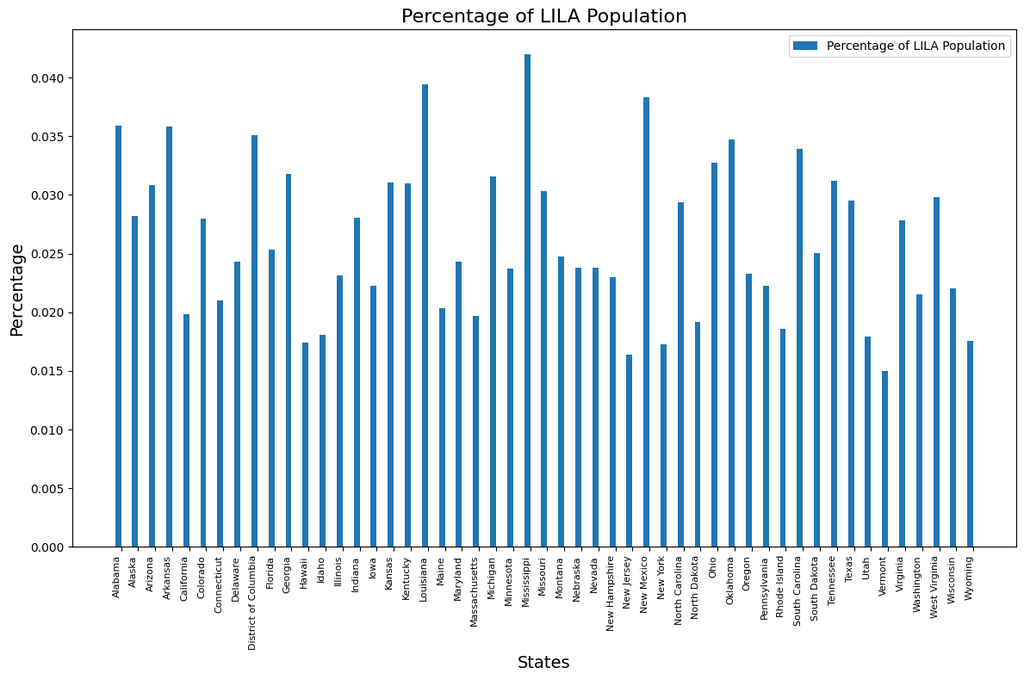

```python
states = cumulative_table.index.tolist()  # List of states
percentage_lila = (cumulative_table['LILATRACTS'] / cumulative_table['POP2010']) * 100  # Percentage of LILA population relative to total population

# Set up the figure and axis with larger size
fig, ax = plt.subplots(figsize=(12, 8))  # Larger figure size
index = np.arange(len(states))
bar_width = 0.35

# Plot the bars
bar1 = ax.bar(index, percentage_lila, bar_width, label='Percentage of LILA Population')

# Add labels, title, and legend
ax.set_xlabel('States', fontsize=14)  # Larger font size
ax.set_ylabel('Percentage', fontsize=14)  # Larger font size
ax.set_title('Percentage of LILA Population', fontsize=16)  # Larger font size
ax.set_xticks(index + bar_width / 2)  # Adjust x-axis ticks to be in the center of each bar
ax.set_xticklabels(states, rotation=90, ha='right', fontsize=8)  # Rotate state labels and smaller font size
ax.legend()

# Show plot
plt.tight_layout()
plt.show()
```

To get a better idea of a coorelation between the percentage of LILA population per race, we decided to make a scatter plot and be able to analyze side to side which one's coorelated the most.

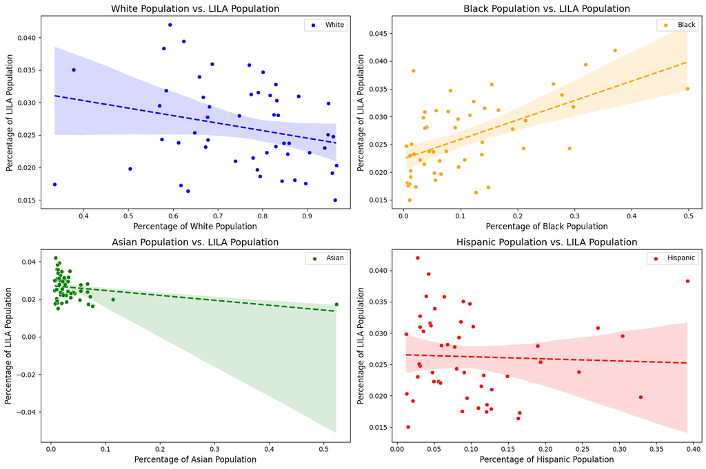

```python
# Assuming cumulative_table is your DataFrame
cumulative_table['Total'] = cumulative_table[['TractWhite', 'TractBlack', 'TractAsian', 'TractHispanic']].sum(axis=1)

# Calculate the percentage of each race for each state
cumulative_table['PercentWhite'] = cumulative_table['TractWhite'] / cumulative_table['Total']
cumulative_table['PercentBlack'] = cumulative_table['TractBlack'] / cumulative_table['Total']
cumulative_table['PercentAsian'] = cumulative_table['TractAsian'] / cumulative_table['Total']
cumulative_table['PercentHispanic'] = cumulative_table['TractHispanic'] / cumulative_table['Total']

# Calculate the percentage of LILA population
percentage_lila = (cumulative_table['LILATRACTS'] / cumulative_table['POP2010']) * 100

# Create a figure with subplots for each racial group
fig, axes = plt.subplots(2, 2, figsize=(15, 10))

# Plot for White population
sns.scatterplot(ax=axes[0, 0], x=cumulative_table['PercentWhite'], y=percentage_lila, color='blue', label='White')
sns.regplot(ax=axes[0, 0], x=cumulative_table['PercentWhite'], y=percentage_lila, scatter=False, color='blue', line_kws={"linestyle":"--"})
axes[0, 0].set_xlabel('Percentage of White Population', fontsize=12)
axes[0, 0].set_ylabel('Percentage of LILA Population', fontsize=12)
axes[0, 0].set_title('White Population vs. LILA Population', fontsize=14)

# Plot for Black population
sns.scatterplot(ax=axes[0, 1], x=cumulative_table['PercentBlack'], y=percentage_lila, color='orange', label='Black')
sns.regplot(ax=axes[0, 1], x=cumulative_table['PercentBlack'], y=percentage_lila, scatter=False, color='orange', line_kws={"linestyle":"--"})
axes[0, 1].set_xlabel('Percentage of Black Population', fontsize=12)
axes[0, 1].set_ylabel('Percentage of LILA Population', fontsize=12)
axes[0, 1].set_title('Black Population vs. LILA Population', fontsize=14)

# Plot for Asian population
sns.scatterplot(ax=axes[1, 0], x=cumulative_table['PercentAsian'], y=percentage_lila, color='green', label='Asian')
sns.regplot(ax=axes[1, 0], x=cumulative_table['PercentAsian'], y=percentage_lila, scatter=False, color='green', line_kws={"linestyle":"--"})
axes[1, 0].set_xlabel('Percentage of Asian Population', fontsize=12)
axes[1, 0].set_ylabel('Percentage of LILA Population', fontsize=12)
axes[1, 0].set_title('Asian Population vs. LILA Population', fontsize=14)

# Plot for Hispanic population
sns.scatterplot(ax=axes[1, 1], x=cumulative_table['PercentHispanic'], y=percentage_lila, color='red', label='Hispanic')
sns.regplot(ax=axes[1, 1], x=cumulative_table['PercentHispanic'], y=percentage_lila, scatter=False, color='red', line_kws={"linestyle":"--"})
axes[1, 1].set_xlabel('Percentage of Hispanic Population', fontsize=12)
axes[1, 1].set_ylabel('Percentage of LILA Population', fontsize=12)
axes[1, 1].set_title('Hispanic Population vs. LILA Population', fontsize=14)

# Adjust layout to prevent overlap and reduce spacing
plt.tight_layout()
plt.show()
```

We would like to primarily focus on race and how diabetes is distributed based on race. Below we work on isolating the total diabetes for four the four races, White, Black, Asian, and Hispanic. This dataset isolates the four races we would like to use later for our pie chart to better visualize the distribution.

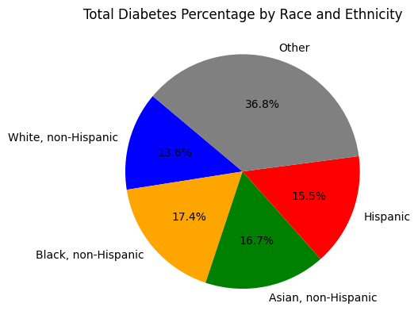

```python
percentage_arr = []
sum = 0
percentage_arr.append(ethnic_df.iloc[10,3])
percentage_arr.append(ethnic_df.iloc[11,3])
percentage_arr.append(ethnic_df.iloc[12,3])
percentage_arr.append(ethnic_df.iloc[13,3])

percentage_arr = [float(v.split()[0]) for v in percentage_arr]

for val in percentage_arr:
    sum += val

other_race = 100 - sum

percentage_arr.append(other_race)

labels = ['White, non-Hispanic', 'Black, non-Hispanic', 'Asian, non-Hispanic', 'Hispanic','Other']
colors = ['blue', 'orange', 'green', 'red','grey']
plt.pie(percentage_arr, labels=labels, colors=colors, autopct='%1.1f%%', startangle=140)
plt.title('Total Diabetes Percentage by Race and Ethnicity')
plt.show()
```

For an inital idea of the average income for the races we were looking at, we decided to do a bar chart to show how the incomes varied per race.

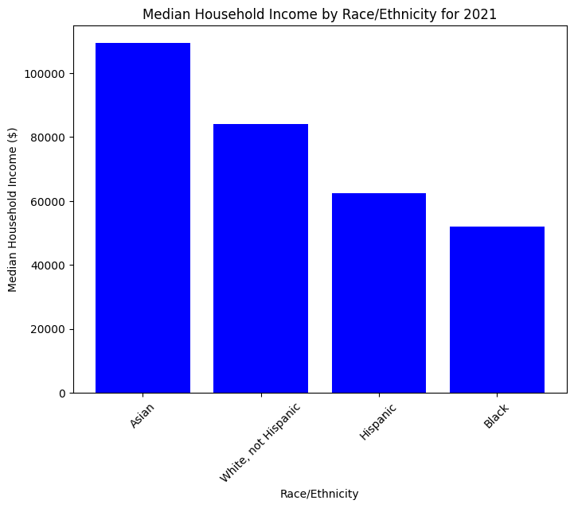

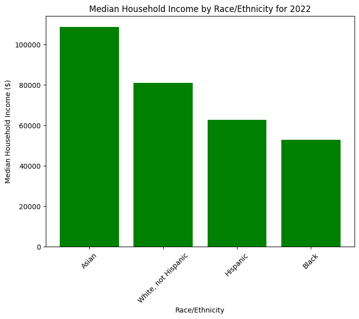

```python
race_ethnicity = ['Asian', 'White, not Hispanic', 'Hispanic', 'Black']

asian_1 = income_df.iloc[1,1].replace("$", "").replace(",", "")
white_1 = income_df.iloc[2,1].replace("$", "").replace(",", "")
hispanic_1 = income_df.iloc[3,1].replace("$", "").replace(",", "")
black_1 = income_df.iloc[4,1].replace("$", "").replace(",", "")
asian_2 = income_df.iloc[1,2].replace("$", "").replace(",", "")
white_2 = income_df.iloc[2,2].replace("$", "").replace(",", "")
hispanic_2 = income_df.iloc[3,2].replace("$", "").replace(",", "")
black_2 = income_df.iloc[4,2].replace("$", "").replace(",", "")


income_2021 = [float(asian_1), float(white_1), float(hispanic_1), float(black_1)]  # 2021 Median Household Income
income_2022 = [float(asian_2), float(white_2), float(hispanic_2), float(black_2)]  # 2022 Median Household Income

plt.figure(figsize=(8, 6))
plt.bar(race_ethnicity, income_2021, color='blue')
plt.xlabel('Race/Ethnicity')
plt.ylabel('Median Household Income ($)')
plt.title('Median Household Income by Race/Ethnicity for 2021')
plt.xticks(rotation=45)  # Rotate labels for better readability
plt.show()

# Graph for 2022
plt.figure(figsize=(8, 6))
plt.bar(race_ethnicity, income_2022, color='green')
plt.xlabel('Race/Ethnicity')
plt.ylabel('Median Household Income ($)')
plt.title('Median Household Income by Race/Ethnicity for 2022')
plt.xticks(rotation=45)  # Rotate labels for better readability
plt.show()
```

**Model: Analysis, Hypothesis Testing and Machine Learning**

Now that we have explored and visualized our variables, we can begin to analyze how effectively certain variables predict the value of another variable. In this case, we are trying to predict the proportion of people with diabetes of a specific race in the United States. The variables we will use are uninsured rate, food insecurity rate, and weekly earnings. In order to do this, we must gather all of our observations in dataframes organized by race.

```python
# Creating dataframes for each group with state and uninsured rate
df_white = pd.DataFrame({'State' : insurance_state_df['Location'], 'Uninsured' : insurance_state_df['White'].astype(float)})
df_black = pd.DataFrame({'State' : insurance_state_df['Location'], 'Uninsured' : insurance_state_df['Black'].astype(float)})
df_hispanic = pd.DataFrame({'State' : insurance_state_df['Location'], 'Uninsured' : insurance_state_df['Hispanic'].astype(float)})
df_asian = pd.DataFrame({'State' : insurance_state_df['Location'], 'Uninsured' : insurance_state_df['Asian/Native Hawaiian and Pacific Islander'].astype(float)})

# Adding food desert rate to dataframes
df_white['Food Desert'] = scaled_lila_population_per_race['White'].astype(float)
df_black['Food Desert'] = scaled_lila_population_per_race['Black'].astype(float)
df_hispanic['Food Desert'] = scaled_lila_population_per_race['Hispanic'].astype(float)
df_asian['Food Desert'] = scaled_lila_population_per_race['Asian'].astype(float)

# Adding weekly earning values to dataframes
df_white['Earnings'] = pivoted_df['White'].astype(float)
df_black['Earnings'] = pivoted_df['Black'].astype(float)
df_hispanic['Earnings'] = pivoted_df['Hispanic/Latino'].astype(float)
df_asian['Earnings'] = pivoted_df['Asian-Pacific Islander'].astype(float)

# Adding diabetes rate to dataframes
df_white['Diabetes Rate'] = diabetes_per_race['DiabetesWhite'].astype(float)
df_black['Diabetes Rate'] = diabetes_per_race['DiabetesBlack'].astype(float)
df_hispanic['Diabetes Rate'] = diabetes_per_race['DiabetesHispanic'].astype(float)
df_asian['Diabetes Rate'] = diabetes_per_race['DiabetesAsian'].astype(float)

df_white.head(10)
```

|  | State | Uninsured | Food Desert | Earnings | Diabetes Rate |
| --- | --- | --- | --- | --- | --- |
| 0 | Alabama | 0.070 | 56.238515 | 1122.683589 | 0.087281 |
| 1 | Alaska | 0.079 | 0.947152 | 956.799950 | 0.071751 |
| 2 | Arizona | 0.080 | 91.988955 | 885.001236 | 0.064025 |
| 3 | Arkansas | 0.093 | 23.440191 | 1054.435662 | 0.095434 |
| 4 | California | 0.043 | 1585.445723 | 1261.061302 | 0.048819 |
| 5 | Colorado | 0.055 | 57.575964 | 1146.704843 | 0.049352 |
| 6 | Connecticut | 0.040 | 20.793075 | 1151.856974 | 0.062113 |
| 7 | Delaware | 0.051 | 1.348585 | 1704.408960 | 0.068494 |
| 8 | District of Columbia | 0.056 | 0.488404 | 1000.972684 | 0.034774 |
| 9 | Florida | 0.124 | 672.865936 | 1002.693115 | 0.067995 |

Now that we have our relevant data organized, we can develop our model. We will use 3 different techniques: Linear Regression, Support Vector Regression, and K Nearest Neighbors Regression.

The first technique we will use is Sklearn's Linear Regression tool. Linear regression is a fundamental statistical technique used to model the relationship between a dependent variable and one or more independent variables. By creating an instance of scikit-learn's LinearRegression class, the tool prepares to find the optimal linear equation that best predicts the dependent variable based on the input variables. This is achieved through a process known as fitting, where the model calculates coefficients that minimize the sum of squared differences between predicted and actual values, known as residuals.

After the model is trained on the training data, it can make predictions on new data using these learned coefficients. The performance of the model is typically evaluated using metrics like Mean Squared Error (MSE) and R-squared. MSE measures the average squared difference between observed actual outcomes and the predicted values, indicating the prediction error. R-squared quantifies the proportion of the variance in the dependent variable that is predictable from the independent variables, offering insight into the accuracy and effectiveness of the model.

To access the official documentation for the LinearRegression model in scikit-learn, which provides comprehensive information on using and understanding this tool, you can visit the following [URL](https://scikit-learn.org/stable/modules/generated/sklearn.linear_model.LinearRegression.html):

This link will take you to the specific section on LinearRegression within the scikit-learn documentation, where you can find detailed descriptions, parameter explanations, examples of usage, and best practices.

```python
def plot_actual_vs_predicted(df, features, target, ax, group_name):
    X = df[features]  # Predictor variables
    y = df[target]  # Response variable

    # Splitting the dataset into training and testing sets
    X_train, X_test, y_train, y_test = train_test_split(X, y, test_size=0.2, random_state=42)

    # Model initialization and training
    model = LinearRegression()
    model.fit(X_train, y_train)

    # Predicting and evaluating the model
    y_pred = model.predict(X_test)
    r_squared = r2_score(y_test, y_pred)
    mse = mean_squared_error(y_test, y_pred)

    # Plotting the actual vs. predicted values
    sns.scatterplot(x=y_test, y=y_pred, alpha=0.6, ax=ax)
    ax.set_xlabel('Actual Diabetes Rates')
    ax.set_ylabel('Predicted Diabetes Rates')
    ax.set_title(f'{group_name}\nR-squared: {r_squared:.4f}, MSE: {mse:.10f}')

    # Line for perfect predictions
    min_val = min(y_test.min(), y_pred.min())
    max_val = max(y_test.max(), y_pred.max())
    ax.plot([min_val, max_val], [min_val, max_val], color='red', lw=2, linestyle='--')

    return r_squared, mse
```

Now we will create a 2x2 grid of subplots with a size of 15x10 inches to compare the relationships between features such as 'Uninsured', 'Food Desert', and 'Earnings' against a 'Diabetes Rate' target across different racial groups (White, Black, Hispanic, Asian).

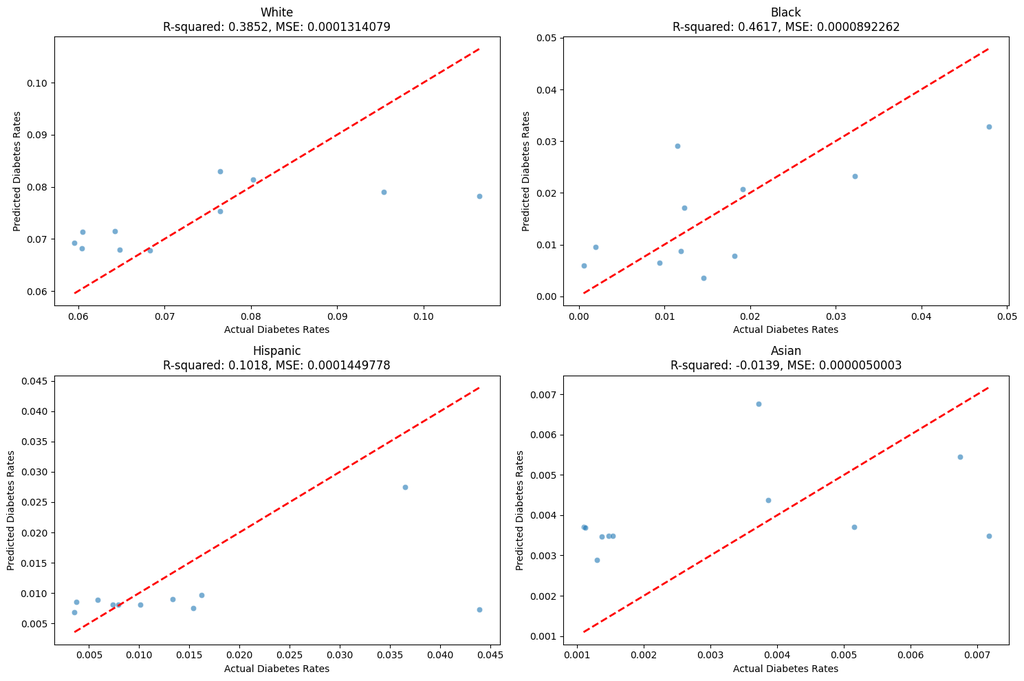

```python
# Creating figures and axes for plots
fig, axes = plt.subplots(2, 2, figsize=(15, 10))
axes = axes.flatten()

# Outlining set of dataframes
dataframes = {
    'White': df_white,
    'Black': df_black,
    'Hispanic': df_hispanic,
    'Asian': df_asian
}

# Setting which variables are included in model
features = ['Uninsured', 'Food Desert', 'Earnings']
target = 'Diabetes Rate'

# Looping through and plotting for each group
for ax, (group, df) in zip(axes, dataframes.items()):
    plot_actual_vs_predicted(df, features, target, ax, group)

plt.tight_layout()
plt.show()
```

The second technique we will use is SKlearn's Support Vector Regression tool. Support Vector Regression (SVR) is a type of modeling technique used to predict continuous outcomes, such as house prices or stock values, rather than placing things into categories. It's based on a method called Support Vector Machine (SVM), which is typically used for classification tasks—deciding whether something belongs to one category or another. SVR works by trying to fit a line (in simple cases) or a curve (in more complex scenarios) as close as possible to the actual values of the data points, while keeping most of the predictions within a certain range from this line or curve. This approach helps the model to be very precise, even when the data has a lot of unusual values or outliers.

When using SVR in practice, it's crucial to prepare the data properly. One important step is to scale the features. This means adjusting the data so that each type of data is treated equally by the model. This can prevent one type of data from overshadowing others just because of the difference in the range of values. After scaling, the data is divided into two parts: one for training the model and the other for testing its predictions. Selecting the right settings, such as the type of curve (linear or more complex), is key to developing an effective model. Finally, the model's success is evaluated using specific metrics, like how close the predictions are to the actual data. Visualizing these predictions through graphs can also help in understanding how well the model is performing.

To learn more about Support Vector Regression (SVR) and how to implement it using scikit-learn, you can visit the [official scikit-learn documentation](https://scikit-learn.org/stable/modules/generated/sklearn.svm.SVR.html). This comprehensive guide provides detailed explanations, parameter overviews, and practical examples to help you effectively apply SVR in your projects. This resource is invaluable for both beginners and advanced users looking to deepen their understanding of regression techniques using support vector machines.

```python
def perform_svr_and_plot(df, features, target, ax, group_name, kernel_type='linear'):
    X = df[features]
    y = df[target]
    X_train, X_test, y_train, y_test = train_test_split(X, y, test_size=0.2, random_state=42)

    # Scaling the features
    scaler = StandardScaler()
    X_train_scaled = scaler.fit_transform(X_train)
    X_test_scaled = scaler.transform(X_test)

    # Initialize and train the SVR model
    model = SVR(kernel=kernel_type)
    model.fit(X_train_scaled, y_train)

    # Predicting and evaluating the model
    y_pred = model.predict(X_test_scaled)
    mse = mean_squared_error(y_test, y_pred)
    r2 = r2_score(y_test, y_pred)

    # Plotting within the provided axis
    sns.scatterplot(x=y_test, y=y_pred, alpha=0.6, ax=ax)
    ax.set_xlabel('Actual Diabetes Rates')
    ax.set_ylabel('Predicted Diabetes Rates')
    ax.set_title(f'{group_name}\nR-squared: {r2:.2f}, MSE: {mse:.10f}')

    # Line for perfect predictions
    min_val = min(np.min(y_test), np.min(y_pred))
    max_val = max(np.max(y_test), np.max(y_pred))
    ax.plot([min_val, max_val], [min_val, max_val], color='red', lw=2, linestyle='--')
```

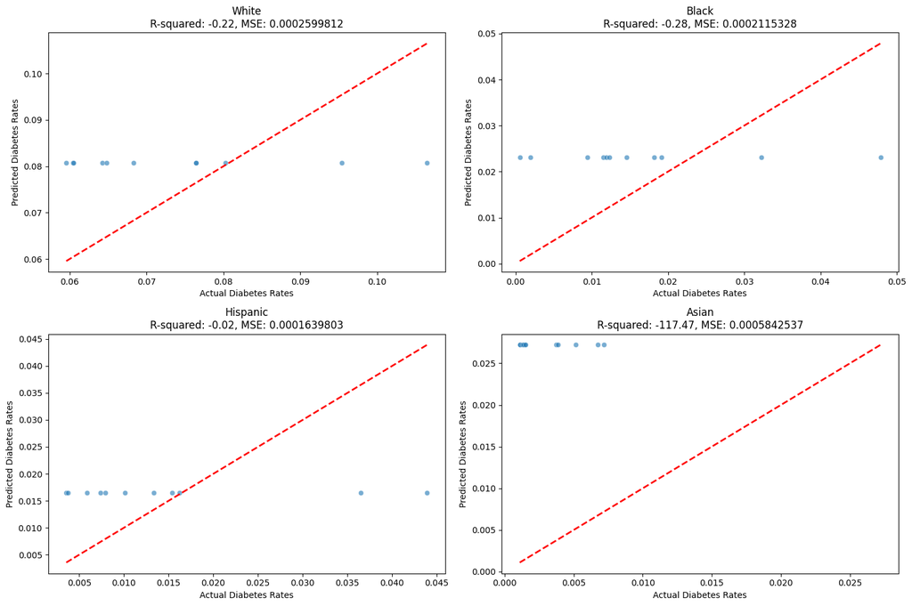

```python
# Creating figure and axes for plotting
fig, axes = plt.subplots(2, 2, figsize=(15, 10))
axes = axes.flatten()

# Outlining dataframes
dataframes = {
    'White': df_white,
    'Black': df_black,
    'Hispanic': df_hispanic,
    'Asian': df_asian
}

# Setting relevant variables for model
features = ['Uninsured', 'Food Desert', 'Earnings']
target = 'Diabetes Rate'

# Looping through each group to plot
for ax, (group, df) in zip(axes, dataframes.items()):
    perform_svr_and_plot(df, features, target, ax, group_name=group, kernel_type='linear')

plt.tight_layout()
plt.show()
```

The third technique we will use is Sklearn's K Neighbors Regressor Tool. The K-Nearest Neighbors (KNN) method is a simple way to predict values like health metrics or financial figures. It looks at new data points and finds the most similar known examples, then averages their values to make a prediction. This technique assumes that similar things exist close together, so by looking at the nearest known points, KNN can make educated guesses about new data.

Before KNN can start making predictions, the data needs to be prepared properly. All the different types of information need to be adjusted so no single type overpowers the others, which is done through a process called scaling. Once the data is ready, the KNN model is trained to understand it and then tested to see how well it predicts new cases. The accuracy of its predictions is checked by comparing the predicted values against actual values, which helps to understand how reliable the model is. This method is flexible and works well even when the data doesn’t follow a straightforward pattern, making it quite useful for solving various real-world problems.

To explore in-depth information about the K-Nearest Neighbors algorithm for regression tasks using scikit-learn, you can visit the official documentation for [KNeighborsRegressor](https://scikit-learn.org/stable/modules/generated/sklearn.neighbors.KNeighborsRegressor.html). This link will direct you to the scikit-learn's official page on KNeighborsRegressor, where you can find all the necessary details about the algorithm, including usage examples, parameter settings, and practical considerations for implementing the model effectively.

```python
def perform_knn_and_plot(df, features, target, ax, group_name, n_neighbors=5):
    X = df[features]
    y = df[target]
    X_train, X_test, y_train, y_test = train_test_split(X, y, test_size=0.2, random_state=42)

    # Scaling the features
    scaler = StandardScaler()
    X_train_scaled = scaler.fit_transform(X_train)
    X_test_scaled = scaler.transform(X_test)

    # Initialize and train KNN
    knn = KNeighborsRegressor(n_neighbors=n_neighbors)
    knn.fit(X_train_scaled, y_train)

    # Predicting and evaluating the model
    y_pred = knn.predict(X_test_scaled)
    mse = mean_squared_error(y_test, y_pred)
    r2 = knn.score(X_test_scaled, y_test)

    # Plotting within the provided axis
    sns.scatterplot(x=y_test, y=y_pred, alpha=0.6, ax=ax)
    ax.set_xlabel('Actual Diabetes Rates')
    ax.set_ylabel('Predicted Diabetes Rates')
    ax.set_title(f'{group_name}\nR-squared: {r2:.2f}, MSE: {mse:.10f}')

    # Line for perfect predictions
    min_val = min(np.min(y_test), np.min(y_pred))
    max_val = max(np.max(y_test), np.max(y_pred))
    ax.plot([min_val, max_val], [min_val, max_val], color='red', lw=2, linestyle='--')
```

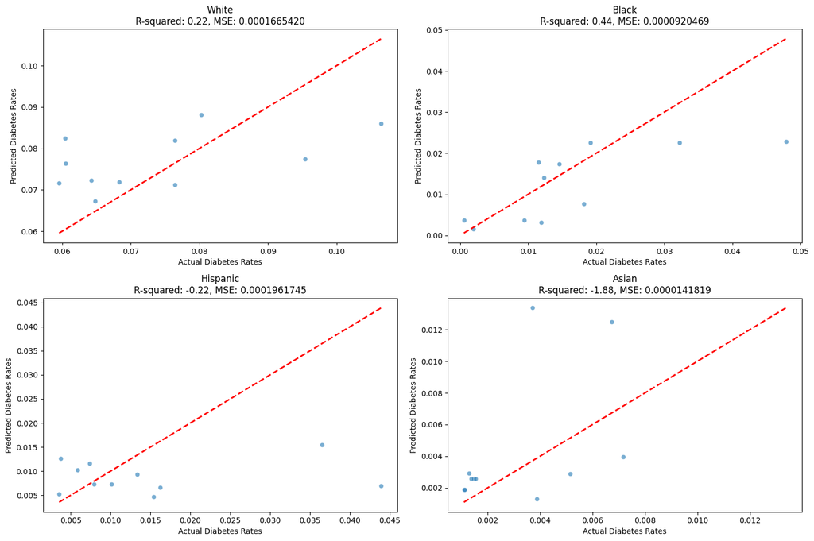

```python
# Creating figures and axes for plotting
fig, axes = plt.subplots(2, 2, figsize=(15, 10))
axes = axes.flatten()

# Outlining dataframe and group names
dataframes = {
    'White': df_white,
    'Black': df_black,
    'Hispanic': df_hispanic,
    'Asian': df_asian
}

# Setting which varibales will be used in model
features = ['Uninsured', 'Food Desert', 'Earnings']
target = 'Diabetes Rate'

# Looping through and plotting each group
for ax, (group, df) in zip(axes, dataframes.items()):
    perform_knn_and_plot(df, features, target, ax, group_name=group)

plt.tight_layout()
plt.show()
```

Let's look at the R-Squared values from our regressions.

```python
# Creating dataframe with all R-Squared values
data = {
    'White': {'Linear Regression': 0.39, 'SVR': -0.22, 'KNN': 0.22},
    'Black': {'Linear Regression': 0.46, 'SVR': -0.28, 'KNN': 0.44},
    'Hispanic': {'Linear Regression': 0.10, 'SVR': -0.02, 'KNN': -0.22},
    'Asian': {'Linear Regression': -0.01, 'SVR': -117.47, 'KNN': -1.88}
}
df = pd.DataFrame(data)

df
```

|  | White | Black | Hispanic | Asian |
| --- | --- | --- | --- | --- |
| Linear Regression | 0.39 | 0.46 | 0.10 | -0.01 |
| SVR | -0.22 | -0.28 | -0.02 | -117.47 |
| KNN | 0.22 | 0.44 | -0.22 | -1.88 |

None of the models performed as well as we would like, but the Linear Regression model is clearly the best option. Let's move forward with this technique and try different combinations of our independent variables to see if that can strengthen our predictions.

Here we are defining a function that will perform linear regression and plotting for one independent variable at a time. This will allow us to see their isolated relationships with diabetes rate.

```python
def linear_regression(df, group_name, ivs, xaxis, ax):
   # Predictor and response variables
    X = ivs # Setting independent variable
    y = df['Diabetes Rate']  # Setting dependent variable

    # Splitting the dataset into training and testing sets
    X_train, X_test, y_train, y_test = train_test_split(X, y, test_size=0.2, random_state=42)

    # Model initialization and training
    model = LinearRegression()
    model.fit(X_train, y_train)

    # Predicting and evaluating the model
    y_pred = model.predict(X_test)
    mse = mean_squared_error(y_test, y_pred)
    r_squared = r2_score(y_test, y_pred)

    # Plotting
    ax.scatter(X_test, y_test, color='blue', label='Actual data')
    line_x = np.linspace(X_test.min(), X_test.max(), 100)
    line_y = model.predict(line_x.reshape(-1, 1))
    ax.plot(line_x, line_y, color='red', linewidth=2, label='Regression Line')
    ax.set_title(f'{group_name}\nR-squared: {r_squared:.4f}, MSE: {mse:.10f}')
    ax.set_xlabel(f'{xaxis}')
    ax.set_ylabel('Diabetes Rate')
    ax.legend()

    return mse, r_squared
```

Now let's plot these individual relationships.

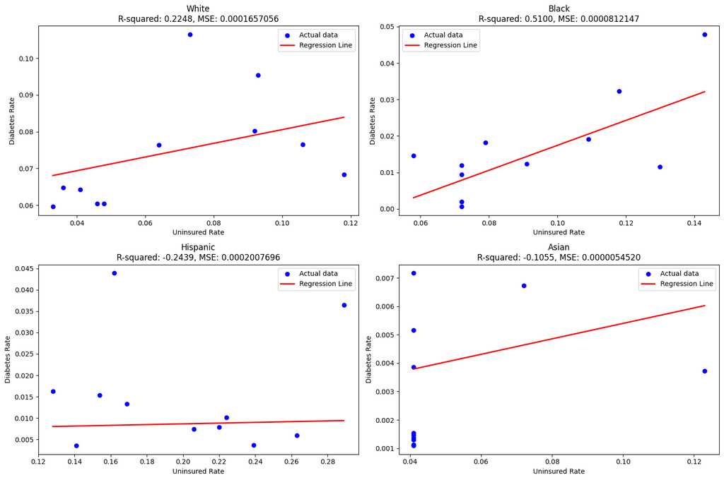

```python
# Creating figures and axes for plotting
fig, axes = plt.subplots(2, 2, figsize=(15, 10))
axes = axes.flatten()

# DataFrames for each racial group
dataframes = {
    'White': df_white,
    'Black': df_black,
    'Hispanic': df_hispanic,
    'Asian': df_asian
}

# Call the function for each group
results = {}
for idx, (group, df) in enumerate(dataframes.items()):
    mse, r_squared = linear_regression(df, group, df[['Uninsured']], 'Uninsured Rate', axes[idx])
    results[group] = {'MSE': mse, 'R-squared': r_squared}

plt.tight_layout()
plt.show()
```

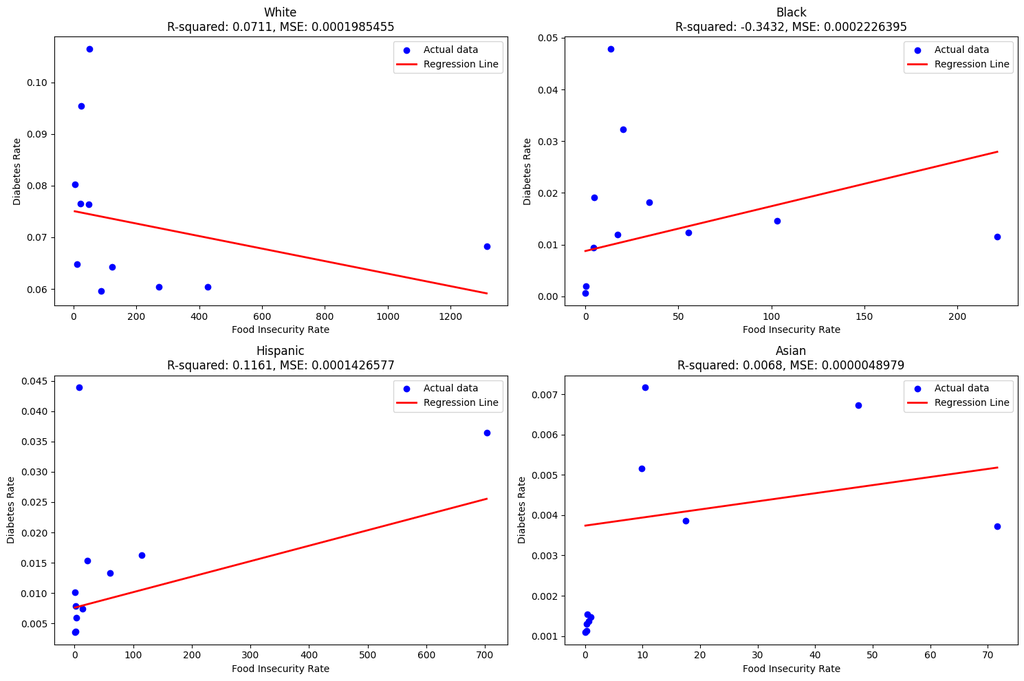

```python
# Creating figures and axes for plotting
fig, axes = plt.subplots(2, 2, figsize=(15, 10))
axes = axes.flatten()

# DataFrames for each racial group
dataframes = {
    'White': df_white,
    'Black': df_black,
    'Hispanic': df_hispanic,
    'Asian': df_asian
}

# Call the function for each group
results = {}
for idx, (group, df) in enumerate(dataframes.items()):
    mse, r_squared = linear_regression(df, group, df[['Food Desert']], 'Food Insecurity Rate', axes[idx])
    results[group] = {'MSE': mse, 'R-squared': r_squared}

plt.tight_layout()
plt.show()
```

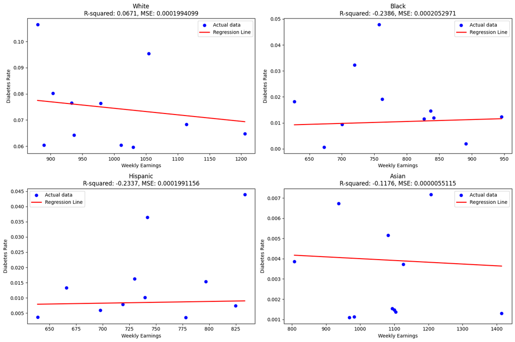

```python
# Creating figures and axes for plotting
fig, axes = plt.subplots(2, 2, figsize=(15, 10))
axes = axes.flatten()

# DataFrames for each racial group
dataframes = {
    'White': df_white,
    'Black': df_black,
    'Hispanic': df_hispanic,
    'Asian': df_asian
}

# Call the function for each group
results = {}
for idx, (group, df) in enumerate(dataframes.items()):
    mse, r_squared = linear_regression(df, group, df[['Earnings']], 'Weekly Earnings', axes[idx])
    results[group] = {'MSE': mse, 'R-squared': r_squared}

plt.tight_layout()
plt.show()
```

Let's look at the R-Squared values from our regressions.

```python
# Creating dataframe with all R-Squared values
data = {
    'White': {'Uninsured': 0.22, 'Food Desert': 0.07, 'Earnings': 0.067},
    'Black': {'Uninsured': 0.51, 'Food Desert': -0.34, 'Earnings': -0.24},
    'Hispanic': {'Uninsured': -0.24, 'Food Desert': 0.12, 'Earnings': -0.23},
    'Asian': {'Uninsured': -0.11, 'Food Desert': 0.01, 'Earnings': -0.12}
}
df = pd.DataFrame(data)

df
```

|  | White | Black | Hispanic | Asian |
| --- | --- | --- | --- | --- |
| Uninsured | 0.220 | 0.51 | -0.24 | -0.11 |
| Food Desert | 0.070 | -0.34 | 0.12 | 0.01 |
| Earnings | 0.067 | -0.24 | -0.23 | -0.12 |

We can learn a significant amount from these values when compared to our previous R-Squared values. Hispanic and Asian models are still not viable when isolated by variable, so that means that our independent variables are not effective predictors for diabetes rate among those demographic groups. However, the Black model performed at its best when the uninsured rate was isolated. The most interesting part of our results is that for the White model, uninsured and food insecurity rate could potentially be viable. Let's test it by making a model based on those variables.

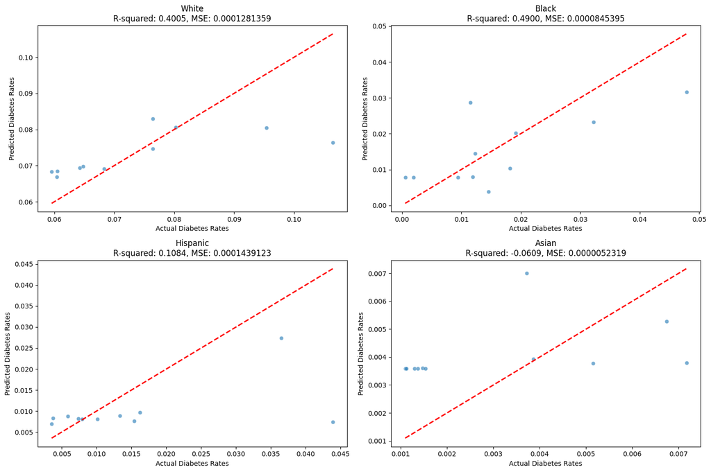

```python
# Creating figures and axes for plotting
fig, axes = plt.subplots(2, 2, figsize=(15, 10))
axes = axes.flatten()

# Outlining dataframes
dataframes = {
    'White': df_white,
    'Black': df_black,
    'Hispanic': df_hispanic,
    'Asian': df_asian
}

# Setting variables for model
features = ['Uninsured', 'Food Desert']
target = 'Diabetes Rate'

# Looping through and plotting for each group
for ax, (group, df) in zip(axes, dataframes.items()):
    plot_actual_vs_predicted(df, features, target, ax, group)

plt.tight_layout()
plt.show()
```

When using uninsured and food insecurity rate to predict diabetes rate, the White model performed at its best. This means that they act as better predictors when removing weekly earnings from the equation.

**Interpretation: Insight & Policy Decision**

The analysis of our models, which aimed to predict diabetes rates among different racial groups based on uninsured rates, food insecurity rates, and weekly earnings, has yielded some intriguing insights. It has become clear that the models' overall poor performance can be attributed to the multifaceted nature of diabetes risk factors. Diabetes, as suggested by these results, is influenced by a variety of determinants, many of which extend beyond simple economic and insurance-related factors to include broader social, environmental, and perhaps unmeasured genetic factors.

Our findings particularly noted that the initial variables chosen did not sufficiently capture the complexity of factors influencing diabetes rates. This aligns with wider health research that underscores the multifactorial basis of diabetes, which includes diet, physical activity, and broader socio-economic factors, alongside genetics. However, there are insights to be gained from the results.

The results from the white demographic indicated an improvement in model performance when weekly earnings were removed from the predictors. This could suggest that for this group, diabetes risk may be less directly tied to immediate financial status than to access to consistent healthcare and reliable nutrition, highlighting the need for policies that enhance these specific areas.

For the black demographic, the observation that the model performed better with only the uninsured rate as a predictor suggests that access to health insurance is possibly a more dominant factor in mitigating diabetes risk than previously considered. This finding is particularly salient given the documented disparities in health coverage across racial lines in the United States, which could potentially exacerbate health outcomes.

Moreover, these insights could guide future research directions. It may be beneficial to incorporate a wider range of variables, such as dietary habits, physical activity levels, and more detailed socio-economic status indicators, to develop more robust models that can predict diabetes risk with greater accuracy. Understanding these relationships in greater depth could also inform more effective community-specific health promotion efforts, ultimately leading to better health outcomes and reduced healthcare costs.

In conclusion, while the initial models did not perform optimally, the insights gained are invaluable. They do not just highlight the limitations of relying solely on certain economic and insurance indicators but also open the door to more targeted, effective public health strategies and research initiatives. By tailoring approaches to the unique needs of each racial group, and considering a broader array of influencing factors, much can be done to reduce the burden of diabetes and improve public health.

If you want to learn more about topics related to this tutorial, please visit these articles!

[Impact of Healthcare Accessibility on Chronic Diseases](https://ncbi.nlm.nih.gov/pmc/articles/PMC10662026/)

Social Determinants of Health and Disease Prevention

Advancements in Predictive Analytics in Healthcare